# Stat 480 - Homework #8

Zahra Khoshmanesh

3/12/2020

## The Joy of Painting with Bob Ross

[figure not shown]

### Questions

1. Download the RMarkdown file with these homework instructions to use as a template for your work. Make sure to replace “Your Name” in the YAML with your name.

```r
# load necessary libraries
library(dplyr)
library(tidyr)
library(ggplot2)
library(forcats)
library(readr)
```

2. The data this week comes from [fivethiryeight](https://github.com/fivethirtyeight/data). The data set includes information on the 403 episodes of “The Joy of Painting”. The accompanying article is published [here](https://fivethirtyeight.com/features/a-statistical-analysis-of-the-work-of-bob-ross/).

```r
# read in the data
bob_ross <- read_csv('https://raw.githubusercontent.com/Stat480-at-ISU/Stat480-at-ISU.github.io/master/homework/data/bob-ross.csv')
```

3. Variables `alizarin_crimson` through `burnt_umber` correspond to the binary presence (0 or 1) of that color in the painting. Gather all of these variables and create a long form of the data, introducing two new variables called `color` and `presence`. Save the result in a data frame called `bob_ross_colors`.

```r
## your answer here
bob_ross %>% glimpse()
```

```
## Observations: 403
## Variables: 65
## $ season           <dbl> 1, 1, 1, 1, 1, 1, 1, 1, 1, 1, 1, 1, 1, 2, 2, 2, 2,...
## $ episode          <dbl> 1, 2, 3, 4, 5, 6, 7, 8, 9, 10, 11, 12, 13, 1, 2, 3...
## $ title            <chr> "A Walk In The Woods", "Mt. Mckinley", "Ebony Suns...
## $ aurora_borealis  <dbl> 0, 0, 0, 0, 0, 0, 0, 0, 0, 0, 0, 0, 0, 0, 0, 0, 0,...
## $ barn             <dbl> 0, 0, 0, 0, 0, 0, 0, 0, 0, 0, 0, 0, 0, 0, 0, 0, 0,...
## $ beach            <dbl> 0, 0, 0, 0, 0, 0, 0, 0, 1, 0, 0, 0, 0, 0, 0, 0, 0,...
## $ boat             <dbl> 0, 0, 0, 0, 0, 0, 0, 0, 0, 0, 0, 0, 0, 0, 0, 0, 0,...
## $ bridge           <dbl> 0, 0, 0, 0, 0, 0, 0, 0, 0, 0, 0, 0, 0, 0, 0, 0, 0,...
## $ building         <dbl> 0, 0, 0, 0, 0, 0, 0, 0, 0, 0, 0, 0, 0, 0, 0, 0, 0,...
## $ bushes           <dbl> 1, 0, 0, 1, 0, 0, 0, 1, 0, 1, 0, 0, 1, 1, 0, 0, 1,...
## $ cabin            <dbl> 0, 1, 1, 0, 0, 1, 0, 0, 0, 0, 0, 0, 0, 0, 0, 0, 1,...
## $ cactus           <dbl> 0, 0, 0, 0, 0, 0, 0, 0, 0, 0, 0, 0, 0, 0, 0, 0, 0,...
## $ cirrus           <dbl> 0, 0, 0, 0, 0, 0, 0, 0, 0, 0, 0, 1, 0, 0, 0, 0, 0,...
```

[output cut: 52 more lines]

```r
bob_ross_colors <- bob_ross %>%
  pivot_longer(cols = alizarin_crimson:burnt_umber,
               names_to = "color",
               values_to = "presence")
bob_ross_colors %>% glimpse()
```

```
## Observations: 5,239
## Variables: 54
## $ season          <dbl> 1, 1, 1, 1, 1, 1, 1, 1, 1, 1, 1, 1, 1, 1, 1, 1, 1, ...
## $ episode         <dbl> 1, 1, 1, 1, 1, 1, 1, 1, 1, 1, 1, 1, 1, 2, 2, 2, 2, ...
## $ title           <chr> "A Walk In The Woods", "A Walk In The Woods", "A Wa...
## $ aurora_borealis <dbl> 0, 0, 0, 0, 0, 0, 0, 0, 0, 0, 0, 0, 0, 0, 0, 0, 0, ...
## $ barn            <dbl> 0, 0, 0, 0, 0, 0, 0, 0, 0, 0, 0, 0, 0, 0, 0, 0, 0, ...
## $ beach           <dbl> 0, 0, 0, 0, 0, 0, 0, 0, 0, 0, 0, 0, 0, 0, 0, 0, 0, ...
## $ boat            <dbl> 0, 0, 0, 0, 0, 0, 0, 0, 0, 0, 0, 0, 0, 0, 0, 0, 0, ...
## $ bridge          <dbl> 0, 0, 0, 0, 0, 0, 0, 0, 0, 0, 0, 0, 0, 0, 0, 0, 0, ...
## $ building        <dbl> 0, 0, 0, 0, 0, 0, 0, 0, 0, 0, 0, 0, 0, 0, 0, 0, 0, ...
## $ bushes          <dbl> 1, 1, 1, 1, 1, 1, 1, 1, 1, 1, 1, 1, 1, 0, 0, 0, 0, ...
## $ cabin           <dbl> 0, 0, 0, 0, 0, 0, 0, 0, 0, 0, 0, 0, 0, 1, 1, 1, 1, ...
## $ cactus          <dbl> 0, 0, 0, 0, 0, 0, 0, 0, 0, 0, 0, 0, 0, 0, 0, 0, 0, ...
## $ cirrus          <dbl> 0, 0, 0, 0, 0, 0, 0, 0, 0, 0, 0, 0, 0, 0, 0, 0, 0, ...
```

[output cut: 41 more lines]

4. Does Bob Ross have a favorite color to paint with? Use the data `bob_ross_colors` as your starting point and for each color calculate the number of times that color was used throughout the series. After using this number to reorder the levels of the variable `color`, create a bar chart using the code below as your starting point and add in the necessary aesthetic mappings within `ggplot(aes( ))`. Describe and summarize the chart.

```
question4_data %>%
  ggplot(aes( )) +
  geom_bar(show.legend = FALSE) +
  coord_flip() +
  theme_minimal() +
  labs(y = "Number of paintings",
       x = "",
       title = "Frequency of colors in Bob Ross Paintings") +
  scale_fill_manual(values = c("#CD5C5C", "#8A3324", "#2C6436", "#3C67A7", "#643914", "#E7BD2F", "#546F1F", "#C36A4A", "#346BB1", "#B58A30", "#F8ED5F", "#372518", "#973B29"))
```

```r
## your answer here
question4_data <- bob_ross_colors %>%
  group_by(color) %>%
  summarise(num_time_used=sum(presence)) %>%
  mutate(color=reorder(color,num_time_used)) %>%
  arrange(desc(num_time_used))

question4_data
```

```
## # A tibble: 13 x 2
##    color            num_time_used
##    <fct>                    <dbl>
##  1 alizarin_crimson           380
##  2 van_dyke_brown             371
##  3 cadmium_yellow             346
##  4 yellow_ochre               327
##  5 phthalo_blue               323
##  6 bright_red                 321
##  7 sap_green                  306
##  8 indian_yellow              292
##  9 dark_sienna                290
## 10 prussian_blue              263
## 11 phthalo_green              116
## 12 burnt_umber                 55
## 13 indian_red                   1
```

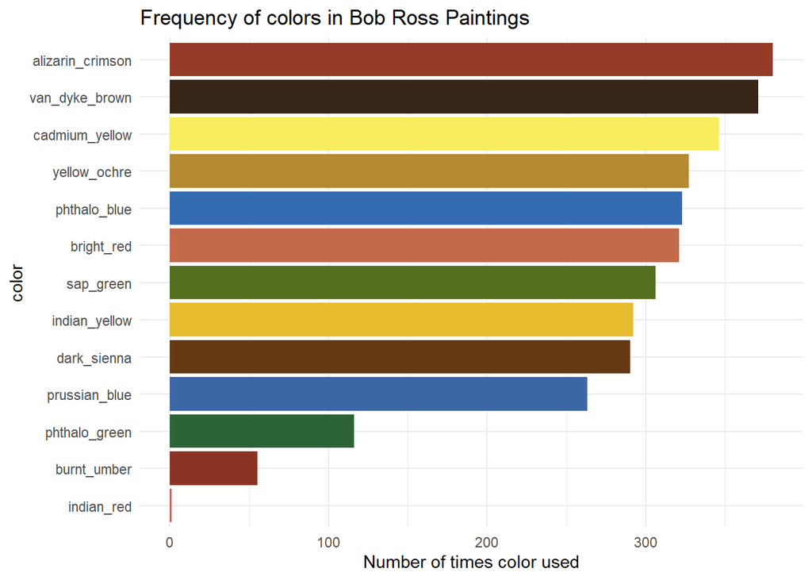

```r
question4_data %>%
  ggplot(aes(x=color,weight=num_time_used,fill=color )) +
  geom_bar(show.legend = FALSE) +
  coord_flip() +
  theme_minimal() +
  labs(y = "Number of times color used",
       x = "color",
       title = "Frequency of colors in Bob Ross Paintings") +
  scale_fill_manual(values = c("#CD5C5C", "#8A3324",
                               "#2C6436", "#3C67A7",
                               "#643914", "#E7BD2F",
                               "#546F1F", "#C36A4A",
                               "#346BB1", "#B58A30",
                               "#F8ED5F", "#372518",
                               "#973B29"))
```

**Describe and summarize the chart**

Bob Ross used alizarin_crimson color 380 times following van_dyke_brown 371 times and cadmium_yellow 346. He used indian_red just once and burnt_umber 55 times.

5. For this question use the original data again. Variables `aurora_borealis` through `winter` correspond to the binary presence (0 or 1) of that element in the painting. Use `pivot_longer()` as shown in class to transform the data into a tidier format with new variables `element` and `presence`. Save the result in a data frame called `bob_ross_elements`.

```r
## your answer here
bob_ross_elements <- bob_ross %>%
  pivot_longer(cols = aurora_borealis:winter,
               names_to = "element",
               values_to = "presence")

bob_ross_elements %>% glimpse()
```

```
## Observations: 19,747
## Variables: 18
## $ season           <dbl> 1, 1, 1, 1, 1, 1, 1, 1, 1, 1, 1, 1, 1, 1, 1, 1, 1,...
## $ episode          <dbl> 1, 1, 1, 1, 1, 1, 1, 1, 1, 1, 1, 1, 1, 1, 1, 1, 1,...
## $ title            <chr> "A Walk In The Woods", "A Walk In The Woods", "A W...
## $ alizarin_crimson <dbl> 1, 1, 1, 1, 1, 1, 1, 1, 1, 1, 1, 1, 1, 1, 1, 1, 1,...
## $ bright_red       <dbl> 1, 1, 1, 1, 1, 1, 1, 1, 1, 1, 1, 1, 1, 1, 1, 1, 1,...
## $ cadmium_yellow   <dbl> 1, 1, 1, 1, 1, 1, 1, 1, 1, 1, 1, 1, 1, 1, 1, 1, 1,...
## $ dark_sienna      <dbl> 0, 0, 0, 0, 0, 0, 0, 0, 0, 0, 0, 0, 0, 0, 0, 0, 0,...
## $ indian_yellow    <dbl> 0, 0, 0, 0, 0, 0, 0, 0, 0, 0, 0, 0, 0, 0, 0, 0, 0,...
## $ phthalo_blue     <dbl> 0, 0, 0, 0, 0, 0, 0, 0, 0, 0, 0, 0, 0, 0, 0, 0, 0,...
## $ phthalo_green    <dbl> 1, 1, 1, 1, 1, 1, 1, 1, 1, 1, 1, 1, 1, 1, 1, 1, 1,...
## $ prussian_blue    <dbl> 1, 1, 1, 1, 1, 1, 1, 1, 1, 1, 1, 1, 1, 1, 1, 1, 1,...
## $ sap_green        <dbl> 1, 1, 1, 1, 1, 1, 1, 1, 1, 1, 1, 1, 1, 1, 1, 1, 1,...
## $ van_dyke_brown   <dbl> 1, 1, 1, 1, 1, 1, 1, 1, 1, 1, 1, 1, 1, 1, 1, 1, 1,...
## $ yellow_ochre     <dbl> 0, 0, 0, 0, 0, 0, 0, 0, 0, 0, 0, 0, 0, 0, 0, 0, 0,...
## $ indian_red       <dbl> 0, 0, 0, 0, 0, 0, 0, 0, 0, 0, 0, 0, 0, 0, 0, 0, 0,...
## $ burnt_umber      <dbl> 0, 0, 0, 0, 0, 0, 0, 0, 0, 0, 0, 0, 0, 0, 0, 0, 0,...
## $ element          <chr> "aurora_borealis", "barn", "beach", "boat", "bridg...
## $ presence         <dbl> 0, 0, 0, 0, 0, 0, 1, 0, 0, 0, 0, 0, 0, 0, 1, 0, 0,...
```

6. What are the most frequent elements in his paintings? Use the data `bob_ross_elements` as your starting point and for each element calculate the number of times that element was included. Then use this number to reorder the levels of `element`. Exclude elements that were featured in fewer than 50 paintings and create a bar chart. Use the code below as your starting point and add in the necessary aesthetic mappings within `ggplot(aes( ))`. Describe and summarize the chart.

```
question6_data %>%
  ggplot(aes( )) +
  geom_bar(fill = "seagreen") +
  coord_flip() +
  theme_minimal() +
  labs(y = "Number of paintings",
       x = "",
       title = "What were most common features in Bob Ross paintings?",
       subtitle = "Paintings by the numbers")
```

```r
## your answer here
question6_data <- bob_ross_elements %>%
  group_by(element) %>%
  summarise(num_used_element=sum(presence)) %>%
  mutate(element=reorder(element, num_used_element)) %>%
  filter(num_used_element >= 50) %>%
  arrange(desc(num_used_element))

question6_data
```

```
## # A tibble: 18 x 2
##    element        num_used_element
##    <fct>                     <dbl>
##  1 tree                        361
##  2 trees                       337
##  3 deciduous                   227
##  4 conifer                     212
##  5 clouds                      179
##  6 mountain                    160
##  7 lake                        143
##  8 grass                       142
##  9 river                       126
## 10 bushes                      120
## 11 snowy_mountain              109
## 12 mountains                    99
## 13 cumulus                      86
## 14 structure                    85
## 15 rocks                        77
## 16 snow                         75
## 17 cabin                        69
## 18 winter                       69
```

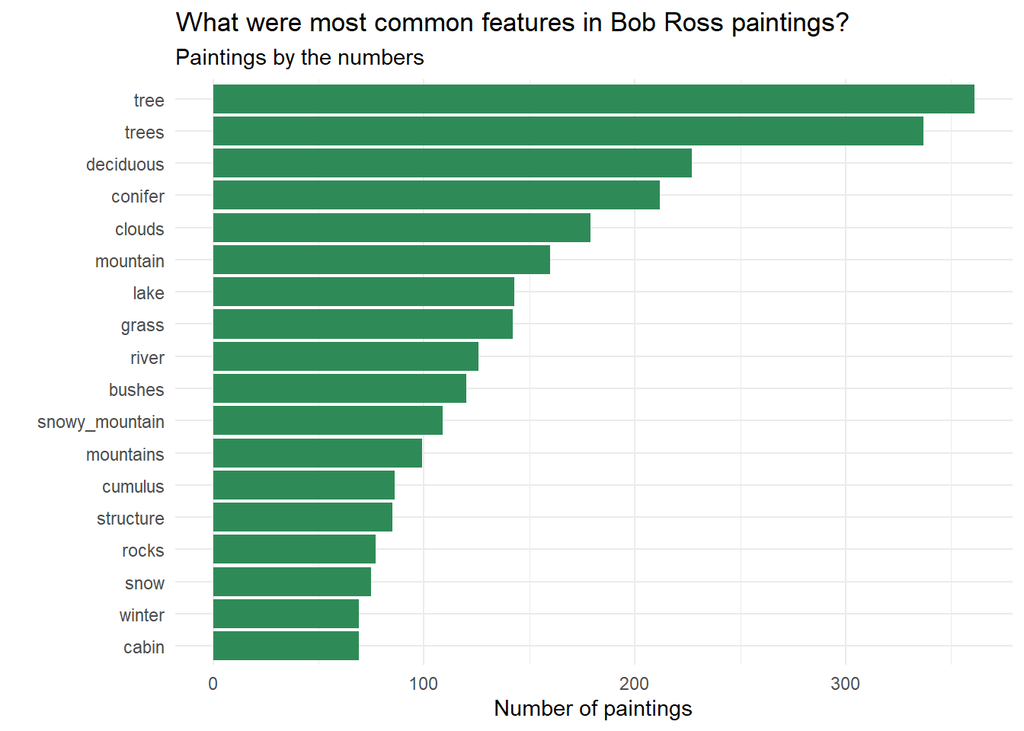

```r
question6_data %>%
  ggplot(aes(x=element,weight=num_used_element )) +
  geom_bar(fill = "seagreen") +
  coord_flip() +
  theme_minimal() +
  labs(y = "Number of paintings",
       x = "",
       title = "What were most common features in Bob Ross paintings?",
       subtitle = "Paintings by the numbers")
```

**Describe and summarize the chart.** The chart shows the most frequent elements that Bob used in his painting. He loves tree since used it a lot in his painting.

7. Did the content of the paintings change over time? We will attempt to answer this question by looking at elements that appeared in more than 90 paintings and their trends over the seasons. Use the data `bob_ross_elements` as your starting point and for each season and element, calculate the number of times an element was included. Exclude elements that were included in less than 90 paintings total. Create a line plot showing number of times an element was included for each season with season on the x-axis and facet by element. Use the code below as your starting point and add in the necessary aesthetic mappings within `ggplot(aes( ))` and add in the faceting. Describe and summarize the chart.

```
question7_data %>%
  ggplot(aes( )) +
  geom_line(color = "deepskyblue") +
  # add faceting here
  labs(y = "Number of paintings with element",
       title = "The content of Bob Ross paintings over time",
       subtitle = "Dashed line is number of episodes in the season") +
  geom_hline(yintercept = 13, lty = 2, color = "grey70") +
  theme_minimal() +
  expand_limits(y = 0)
```

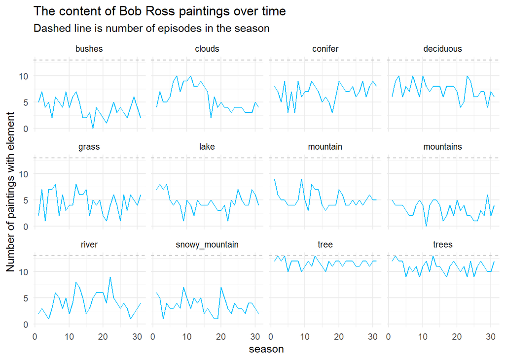

```r
## your answer here
question7_data <- bob_ross_elements %>%
  group_by(element) %>%
  mutate(num_times=sum(presence)) %>%
  filter(num_times > 90) %>%
  group_by(season,element) %>%
  summarise(appeared=sum(presence))

question7_data %>%
  ggplot(aes(x=season,y=appeared )) +
  geom_line(color = "deepskyblue") +
  facet_wrap(~element)+
  labs(y = "Number of paintings with element",
       title = "The content of Bob Ross paintings over time",
       subtitle = "Dashed line is number of episodes in the season") +
  geom_hline(yintercept = 13, lty = 2, color = "grey70") +
  theme_minimal() +
  expand_limits(y = 0)
```